# DATA 606 Lab 2

(Chapter 2 - Summarizing Data)

Donny Lofland

9/07/2019

Source files: [https://github.com/djlofland/DATA606_F2019/tree/master/Homework2]

```r
library(formattable)
```

**Stats scores**. (2.33, p. 78) Below are the final exam scores of twenty introductory statistics students.

57, 66, 69, 71, 72, 73, 74, 77, 78, 78, 79, 79, 81, 81, 82, 83, 83, 88, 89, 94

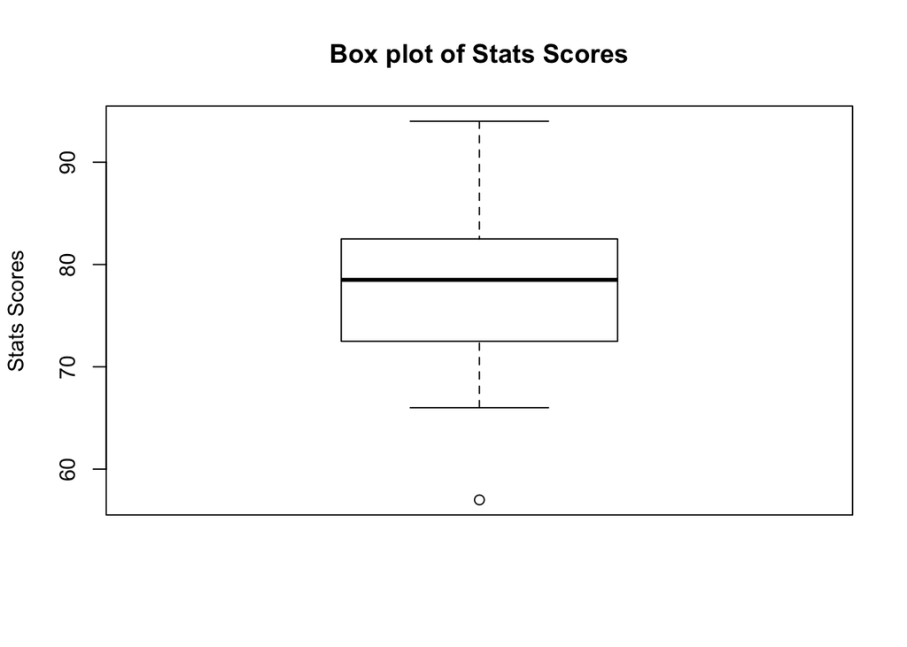

```r
scores <- c(57, 66, 69, 71, 72, 73, 74, 77, 78, 78, 79, 79, 81, 81, 82, 83, 83, 88, 89, 94)
boxplot(scores, ylab='Stats Scores', main="Box plot of Stats Scores")
```

**Mix-and-match**. (2.10, p. 57) Describe the distribution in the histograms below and match them to the box plots.

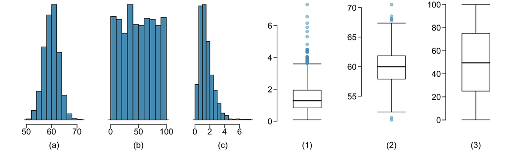

> a: Normal, b: Uniform and c: Right Skewed

> a => 2, b => 3 and c => 1

**Distributions and appropriate statistics, Part II**. (2.16, p. 59) For each of the following, state whether you expect the distribution to be symmetric, right skewed, or left skewed. Also specify whether the mean or median would best represent a typical observation in the data, and whether the variability of observations would be best represented using the standard deviation or IQR. Explain your reasoning.

### Exercise 1

1. Housing prices in a country where 25% of the houses cost below $350,000, 50% of the houses cost below $450,000, 75% of the houses cost below $1,000,000 and there are a meaningful number of houses that cost more than $6,000,000.

> **Right Skewed** - The majority of the pric distribution is on the left with a longtail of high prices to the right. Use **median** and **IQR** to reduce the influence of the high priced homes.

### Exercise 2

2. Housing prices in a country where 25% of the houses cost below $300,000, 50% of the houses cost below $600,000, 75% of the houses cost below $900,000 and very few houses that cost more than $1,200,000.

> **Symmetric**, use **mean** and **standard deviation** since there are few outliers, we expect mean and median to be similar.

### Exercise 3

3. Number of alcoholic drinks consumed by college students in a given week. Assume that most of these students don’t drink since they are under 21 years old, and only a few drink excessively.

> **Right skewed** and use **median** and **IQR** to reduce influence of outliers to the right.

> *Note: I might segment this sample into separate drinkers vs non-drinkers, then look just at the drinkers distribution. I suspect it will also be right skewed where most drinkers only have a few drink and there are a few outliers that binge. However, once we remove the 0 drinks, this probaly better represents the real distribution we are interested in. I would again use **median** and **IQR** to remove the influce of bingers on this distribution.*

### Exercise 4

4. Annual salaries of the employees at a Fortune 500 company where only a few high level executives earn much higher salaries than the all other employees.

> If outliers are included then its an extremely **right skewed**. I would use the **median** to remove influnce of the few outliers and use **IQR** to described the distribution.

> *Note: If we removed the outliers and the remaining distribution were closer to normal, then we could consider using **mean** and **SD***

**Heart transplants.** (2.26, p. 76) The Stanford University Heart Transplant Study was conducted to determine whether an experimental heart transplant program increased lifespan. Each patient entering the program was designated an official heart transplant candidate, meaning that he was gravely ill and would most likely benefit from a new heart. Some patients got a transplant and some did not. The variable *transplant* indicates which group the patients were in; patients in the treatment group got a transplant and those in the control group did not. Of the 34 patients in the control group, 30 died. Of the 69 people in the treatment group, 45 died. Another variable called *survived* was used to indicate whether or not the patient was alive at the end of the study.

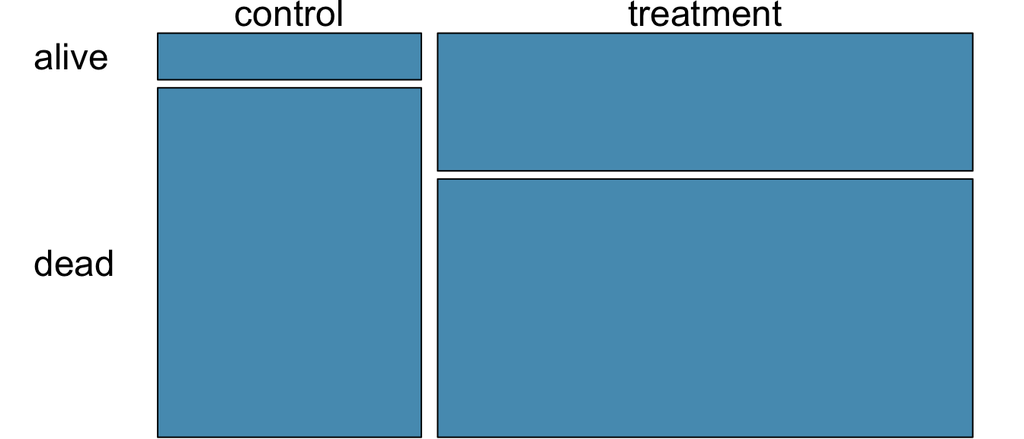

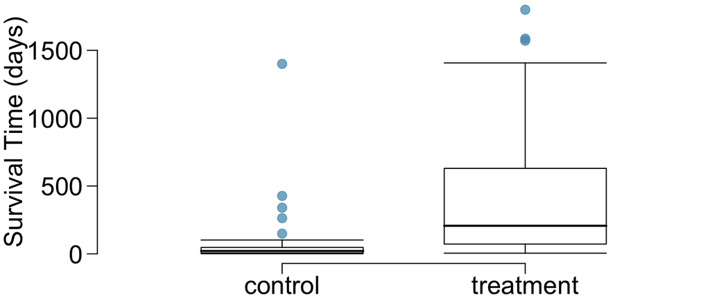

### Exercise 5

1. Based on the mosaic plot, is survival independent of whether or not the patient got a transplant? Explain your reasoning.

> Survival is **dependent** on whether the patient got a treatment. Looking at the plot, there is a clear difference in the portion of patients surviving depending on which group they were in. If survival was *independent*, then we’d expect to see similar portions surviving in each group.

### Exercise 6

2. What do the box plots below suggest about the efficacy (effectiveness) of the heart transplant treatment.

> Transpant was quite effective at improving survival time. Patients receiving the heart show significant increase in median and IQR range with many patients living longer than 75% quartile.

### Exercise 7

3. What proportion of patients in the treatment group and what proportion of patients in the control group died?

```r
control_died <- 30/34
treat_died <- 45/69
```

> 88.24% of the control group died, 65.22% of the treatment group died.

### Exercise 8

4. One approach for investigating whether or not the treatment is effective is to use a randomization technique.

```r
died <- (30+45)
alive <- (34+69)
treatment <- 69
control <- 34
```

### Exercise 9

1. What are the claims being tested?

> H<sub>0</sub>: Independenc model where the **treatment and outcome are independent** and the treatment had no influenc on the outcome.

> H<sub>A</sub>: Aleternate Model where the variables are **not** independent and the treatment affected the outcome, i.e. the **outcome was dependent on the presence of the treatment**.

### Exercise 10

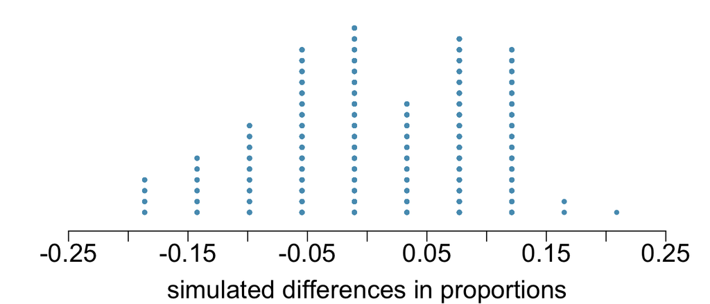

```r
obs_control_died <- 30/34
obs_treat_died <- 45/69
obs_diff <- obs_control_died - obs_treat_died
```

> Our observed difference of 0.230179 falls near the tail of the distribution assuming no treatment effect. This suggests that the treatment difference is **very unlikely** to be due to chance and we conclude **the treatment affected the outcome**.